# Analysis of Daily Walking Data

## Code to describe and show a strategy for imputing missing data

```r
# Number of missing values by day
NAsByDay <- summarize(activity, NAs = sum((is.na(steps))))
table(NAsByDay$NAs) # 53 days have no NAs, 8 days have only NAs
```

```
##
##   0 288
##  53   8
```

Since all days have either no missing values or only missing values (as there are 288 5-minute intervals in a day), we have to impute by interval. For every interval in each day with missing data, I will set the number of steps to the average for that interval in the days that have data.

```r
# The dates with missing data
missingDays <-NAsByDay$date[which(NAsByDay$NAs!=0)]

# Setting the values to the average by interval for each of the 8 days with missing data
imputedValues <- activity %>% filter(date %in% missingDays) %>%
  group_by(interval) %>%
  mutate(steps = intervalSteps[intervalSteps$interval==interval,]$intMean) %>%
  ungroup()

# Combine the imputed values with the exisitng values in the activity dataset
recombinedActivity <- activity
recombinedActivity[recombinedActivity$date %in% missingDays,]$steps <- imputedValues$steps
```

Histogram of the total number of steps taken each day after missing values are imputed

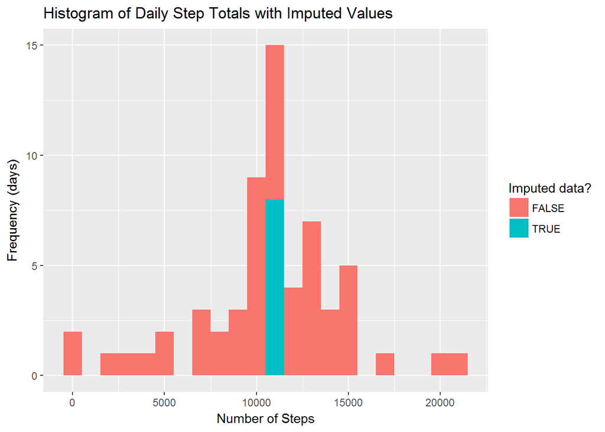

```r
dailyStepsRecombined <- recombinedActivity %>%
  group_by(date) %>%
  summarize(dsum = sum(steps))

# Plot a histogram of number of steps per day for all days
ggplot(data = dailyStepsRecombined, aes(x = dsum, fill = date %in% missingDays)) +
  geom_histogram(binwidth = 1000) +
  labs(title = "Histogram of Daily Step Totals with Imputed Values", x = "Number of Steps", y = "Frequency (days)") +
  scale_fill_discrete(name="Imputed data?")
```

The histogram shows that the imputed data in ni the middle of the distribution, so imputing in this manner effectively reduces the apparent variance and increases the apparent concentration the distribution near the mean.

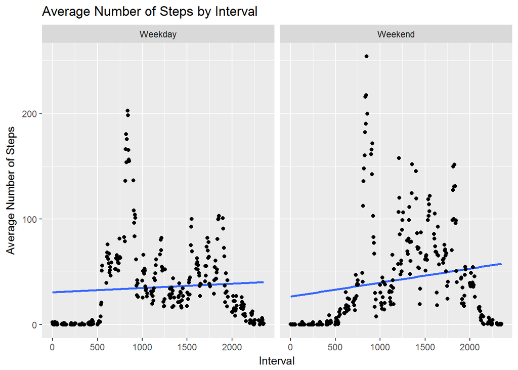

```r
recombinedActivity <- recombinedActivity %>% mutate(wkday = wday(date) %in% c(6,7))
recombinedActivity$wkday <- factor(recombinedActivity$wkday, labels = c('Weekday', "Weekend"))

wkdayMeans <- recombinedActivity %>% group_by(wkday, interval) %>%
  summarize(intMean = mean(steps))

# plot average steps by interval forr weekends and weekdays
ggplot(data = wkdayMeans, aes(x = interval, y = intMean)) +
  geom_smooth(method = "lm", se = F) +
  geom_point() +
  labs(title = "Average Number of Steps by Interval", x = "Interval", y = "Average Number of Steps") +
  facet_wrap( ~ wkday)
```